# ФББ - R - Домашнее задание №5

Данил Сидиков

02 10 2023

# Подгрузка пакетов

```r
library('tidyverse') #загрузим установленный пакет tidyverse в текущую R сессию
```

# Задание №1

## Задание 1.1

> Ваш коллега собрал данные о том, сколько людей появилось на своих рабочих местах в лаборатории за прошедшую неделю. Давайте изобразим эти данные в виде столбчатой диаграммы. Подпишите график, оси, добавьте цвета, поиграйте с дизайном. Обратите внимание, что дни недели на графике должны идти в правильном порядке (постарайтесь добиться этого самым кратким способом).

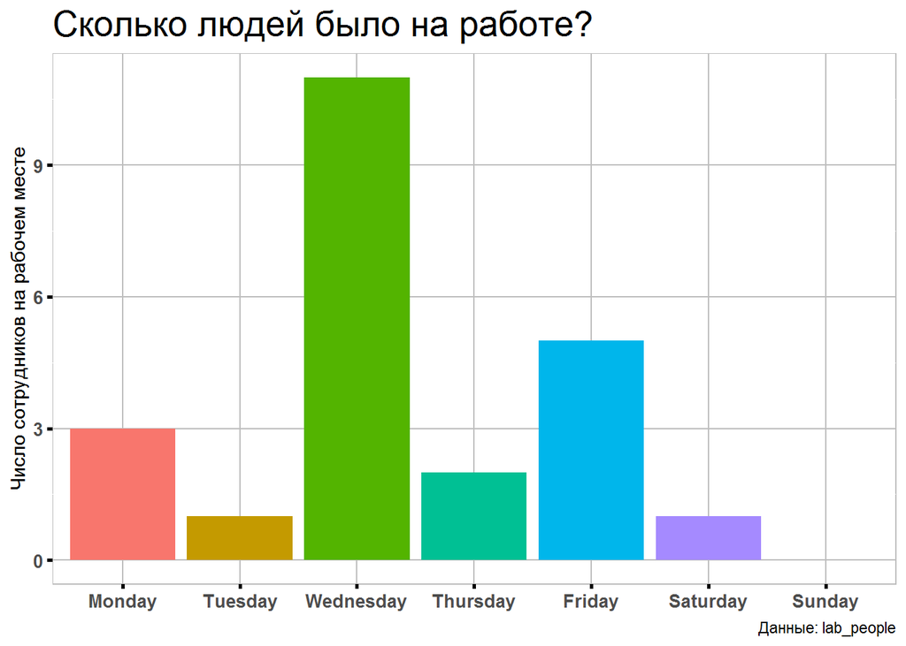

```r
lab_people <- tibble(
  day = c("Monday", "Tuesday", "Wednesday", "Thursday", "Friday", "Saturday", "Sunday"),
  n_people = c(3, 1, 11, 2, 5, 1, 0))


p <- ggplot(lab_people, aes(x = factor(day, levels = day), y = n_people, fill= factor(day, levels = day))) +
  #Зададим barplot
    geom_bar(stat = "identity") +
  #Введем обозначения
    labs(title="Сколько людей было на работе?",
         caption = "Данные: lab_people",
         y = "Число сотрудников на рабочем месте") +
  #Зададим собственную тему
    theme(plot.background = element_blank(),
          panel.background = element_rect(fill = "transparent", colour = "gray"),
          panel.grid.major = element_line(colour = "grey"),
          plot.title = element_text(size = 20),
          axis.text = element_text(size = 10,
                                   face = "bold"),
          axis.title.x = element_blank(),
          axis.ticks = element_line(color = "black",
                                    linewidth = 1),
          legend.position = "none")
p
```

## Задание 1.2

> Соседней лаборатории понравился эксперимент вашего коллеги и они тоже решили собрать данные о количестве людей на рабочих местах в разные дни. Теперь у вас есть данные из двух лабораторий, давайте их визуализируем на одном графике с помощью столбчатой диаграммы. Подпишите график, оси, добавьте цвета, поиграйте с дизайном. Дни недели на графике должны быть указаны в правильном порядке.

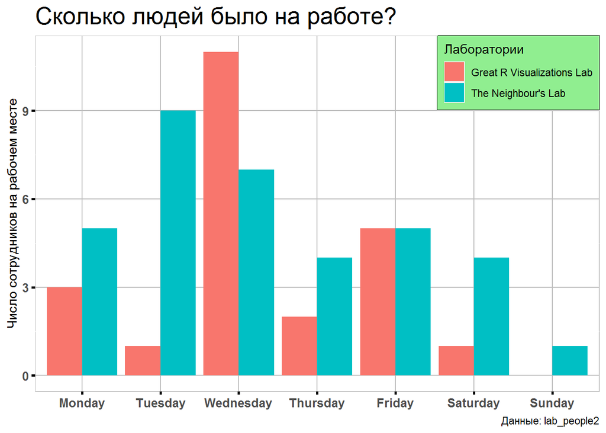

```r
lab_people2 <- tibble(
  lab = c("Great R Visualizations Lab", "The Neighbour's Lab"),
  Monday = c(3, 5),
  Tuesday = c(1, 9),
  Wednesday = c(11, 7),
  Thursday = c(2, 4),
  Friday = c(5, 5),
  Saturday = c(1, 4),
  Sunday = c(0, 1))

lab2 <- gather(lab_people2, day, count, -lab) #преобразуем в длинный формат

p <- ggplot(lab2, aes(x = factor(day, levels = unique(day)), y = count, fill = lab)) +
  #Зададим barplot
    geom_bar(stat = "identity", position = "dodge") +
  #Введем обозначения
    labs(title="Сколько людей было на работе?",
         caption = "Данные: lab_people2",
         x = "Дни недели",
         y = "Число сотрудников на рабочем месте") +
    labs(fill = "Лаборатории")+
  #Зададим собственную тему
    theme(plot.background = element_blank(),
          panel.background = element_rect(fill = "transparent", colour = "gray"),
          panel.grid.major = element_line(colour = "grey"),
          plot.title = element_text(size = 20),
          axis.text = element_text(size = 10,
                                   face = "bold"),
          axis.title.x = element_blank(),
          axis.ticks = element_line(color = "black",
                                    linewidth = 1),
          legend.position = c(1, 1),
          legend.justification = c(1, 1),
          legend.background = element_rect(fill = "lightgreen"),
          legend.box.background = element_rect(fill = "transparent"))
p
```

# Задание №2

> Прочитайте датасет про исчезнувшие виды растений по ссылке https://raw.githubusercontent.com/rfordatascience/tidytuesday/master/data/2020/2020-08-18/plants.csv.

> Изучите датасет!

> Что в нем есть:
- binomial_name - название вида растения,
- country - страна произрастания,
- continent - континент произрастания,
- group - таксономическая группа (Цветковое растение - Flowering plant, и т.д.),
- year_last_seen - период, когда было замечено в природе последний раз,
- threat_ и action_ - виды угроз и действий по сохранению вида,
- red_list_category - категория в Красной книге: Extinct или Extinct in the Wild.

> Больше информации о датасете по ссылке: https://github.com/rfordatascience/tidytuesday/blob/master/data/2020/2020-08-18/readme.md.

> Постройте столбчатую диаграмму числа исчезнувших видов цветковых растений и не-цветковых растений на каждом континенте.

> Пояснения:
- В колонке group оставьте группу Flowering plants (цветковые растения), остальные группы растений объедините в группу Non-flowering plants (не-цветковые растения). Используйте возможности пакета forcats.
- Посчитайте число исчезнувших видов (Extinct) по каждому континенту, в каждой таксономической группе (Flowering plants и Non-flowering plants).
- Нарисуйте группированную столбчатую диаграмму (2 отдельных столбца, для Flowering plants и Non-flowering plants, расположенные рядом). По горизонтали расположите континенты.
- Пусть континенты будут расположены в порядке убывания количества стран на них.
- Осмысленно подпишите оси.
- Перенесите легенду наверх, уберите название легенды.
- Обозначьте Flowering plants желтым и Non-flowering plants зеленым.

```r
plants <- read_csv("https://raw.githubusercontent.com/rfordatascience/tidytuesday/master/data/2020/2020-08-18/plants.csv")
head(plants) #так выглядят мои данные
```

```
## # A tibble: 6 x 24
##   binomial_name      country continent group year_last_seen threat_AA threat_BRU
##   <chr>              <chr>   <chr>     <chr> <chr>              <dbl>      <dbl>
## 1 Abutilon pitcairn~ Pitcai~ Oceania   Flow~ 2000-2020              0          0
## 2 Acaena exigua      United~ North Am~ Flow~ 1980-1999              0          0
## 3 Acalypha dikuluwe~ Congo   Africa    Flow~ 1940-1959              0          0
## 4 Acalypha rubriner~ Saint ~ Africa    Flow~ Before 1900            1          1
## 5 Acalypha wilderi   Cook I~ Oceania   Flow~ 1920-1939              1          0
## 6 Acer hilaense      China   Asia      Flow~ 1920-1939              0          0
## # i 17 more variables: threat_RCD <dbl>, threat_ISGD <dbl>, threat_EPM <dbl>,
## #   threat_CC <dbl>, threat_HID <dbl>, threat_P <dbl>, threat_TS <dbl>,
## #   threat_NSM <dbl>, threat_GE <dbl>, threat_NA <dbl>, action_LWP <dbl>,
## #   action_SM <dbl>, action_LP <dbl>, action_RM <dbl>, action_EA <dbl>,
## #   action_NA <dbl>, red_list_category <chr>
```

```r
plants$group <- fct_collapse(plants$group, #Cгруппируем данные по условию
             Flowering = "Flowering plants",
             Non_flowering = c("Non-flowering plants",unique(plants$group)[!(unique(plants$group) %in% "Flowering Plant")]))
plants_summary <- plants %>%  #сформируем датафрейм
  group_by(continent, group, red_list_category) %>%
  summarise(count = n()) %>%
  filter(red_list_category == "Extinct")
head(plants_summary) #Сформируем датафрейм для формирования графика
```

```
## # A tibble: 6 x 4
## # Groups:   continent, group [6]
##   continent group           red_list_category count
##   <chr>     <fct>           <chr>             <int>
## 1 Africa    Non_flowering   Extinct               8
## 2 Africa    Flowering Plant Extinct             197
## 3 Asia      Non_flowering   Extinct               3
## 4 Asia      Flowering Plant Extinct              45
## 5 Europe    Non_flowering   Extinct               3
## 6 Europe    Flowering Plant Extinct               7
```

```r
by_country <- plants %>% #Сгруппируем данные по континентам и странам на них
  group_by(continent, country) %>%
  summarise(count = n())
N <- pull(count(by_country, continent, sort = TRUE)["continent"])
count(by_country, continent, sort = TRUE) # Упорядочим континенты в порядке убывания количества стран в них в ИСХОДНОМ ДАТАСЕТЕ!!!!!! А не географически
```

```
## # A tibble: 6 x 2
## # Groups:   continent [6]
##   continent         n
##   <chr>         <int>
## 1 Africa           24
## 2 Asia             11
## 3 North America    10
## 4 Oceania          10
## 5 Europe            9
## 6 South America     9
```

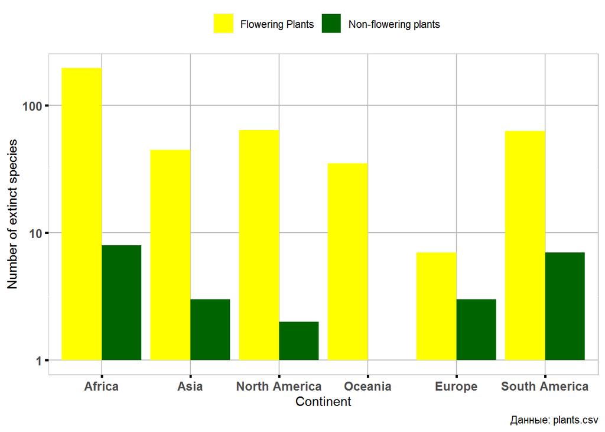

```r
p <- ggplot(plants_summary, aes(x = factor(continent, levels = N), y = count, fill = factor(group, levels = unique(plants$group)))) +
  #Зададим barplot
    geom_bar(stat = "identity", position = "dodge") +
  #Введем обозначения
    labs(title="?",
         caption = "Данные: plants.csv",
         x = "Continent",
         y = "Number of extinct species") +
    scale_fill_manual(values = c("yellow","darkgreen"),
                      labels = c("Flowering Plants","Non-flowering plants"))  +
  #Масштабируем оси графика
    scale_y_continuous(trans='log10') +
  #Зададим собственную тему
    theme(plot.background = element_blank(),
          panel.background = element_rect(fill = "transparent", colour = "gray"),
          panel.grid.major = element_line(colour = "grey"),
          plot.title = element_blank(),
          axis.text = element_text(size = 10,
                                   face = "bold"),
          axis.ticks = element_line(color = "black",
                                    linewidth = 1),
          legend.position = "top",
          legend.title = element_blank())
p
```

# Задание №3

> Загрузите датасет, содержащий динамику использования сои в пищевой и непищевой промышленности за несколько последних десятков лет. Ссылка для скачивания: https://raw.githubusercontent.com/rfordatascience/tidytuesday/master/data/2021/2021-04-06/soybean_use.csv.

> Изучите датасет! Про него можно прочитать дополнительно, например, здесь: https://github.com/rfordatascience/tidytuesday/blob/master/data/2021/2021-04-06/readme.md.

> Информация про датасет:
- entity - континент, часть континента или страна,
- code - код страны,
- year - год,
- human_food - сколько сои было использованно в пищевой промышленности (в тоннах),
- animal_feed - сколько сои было использовано в производстве кормов для животных (в тоннах),
- processed - сколько сои было использовано в непищевой промышленности (производство биотоплива и т.д.) (в тоннах).

> Отберите для анализа данные только по 6 континентам: c(“Africa”, “Europe”, “Asia”, “Northern America”, “South America”, “Australia & New Zealand”), за 33 года - 1981-2013. Нарисуйте столбчатую диаграмму, которая бы изображала среднее количество сои по трем типам промышленности, использованной за 33 года на всех 6 обитаемых континентах. Изобразите разброс 3/4 SD (чтобы линии разброса выровнялись со столбцами, возможно, вам понадобится параметр position = position_dodge(width = 0.9)). Отсортируйте континенты по среднему количеству сои, использованной во всех областях промышленности за исследуемый период. Логарифмируйте ось Y с помощью подходящей функции scale_y_*. Измените формат числовых подписей по оси Y.

> Добавьте осознанные названия осей. Поверните названия континентов, чтобы они отображались целиком, на 45 градусов. Уберите название легенды и поменяйте цвета (например, на c(“#ffb4a2”, “#e5989b”, “#b5838d”)) и названия категорий промышленности в легенде (чтобы было более приятно читать).

```r
#Прочитаем данные
soa <- read_csv("https://raw.githubusercontent.com/rfordatascience/tidytuesday/master/data/2021/2021-04-06/soybean_use.csv") #Прочитаем датасет
#Покажем данные
head(soa)
```

```
## # A tibble: 6 x 6
##   entity code   year human_food animal_feed processed
##   <chr>  <chr> <dbl>      <dbl>       <dbl>     <dbl>
## 1 Africa <NA>   1961      33000        6000     14000
## 2 Africa <NA>   1962      43000        7000     17000
## 3 Africa <NA>   1963      31000        7000      5000
## 4 Africa <NA>   1964      43000        6000     14000
## 5 Africa <NA>   1965      34000        6000     12000
## 6 Africa <NA>   1966      41000        6000      2000
```

```r
#Отберем данные по условию
soaf <- filter(soa,between(year, 1981,2013) & (entity %in% c("Africa", "Europe", "Asia","Northern America", "South America", "Australia & New Zealand")))

#Сгруппируем данные и найдем средние по континетам и по типам промышленности
bart <- soaf %>%
    group_by(entity) %>%
    summarise(
        human_food = mean(human_food),
        animal_feed = mean(animal_feed),
        processed = mean(processed)
    )
#Отсортируем по сумме средних значений
bart <- bart %>%
    arrange(desc(human_food + animal_feed + processed))

#Cгруппируем данные по SD
bart_sd <- soaf %>%
    group_by(entity) %>%
    summarise(
        human_food = 3*sd(human_food, na.rm = TRUE)/4,
        animal_feed = 3*sd(animal_feed, na.rm = TRUE)/4,
        processed = 3*sd(processed, na.rm = TRUE)/4
    )
#Преобразуем в длинный формат
barts <- gather(bart, type, avg, -entity)
bartsd <- gather(bart_sd, type, sd, -entity)

#Итоговые датасет
soy <- right_join(barts, bartsd, by = c("entity","type"))

soy #Выведем данные итогового датасета
```

```
## # A tibble: 18 x 4
##    entity                  type              avg        sd
##    <chr>                   <chr>           <dbl>     <dbl>
##  1 Asia                    human_food   7330364.   732573.
##  2 South America           human_food    481424.   142795.
##  3 Northern America        human_food     25485.     8197.
##  4 Europe                  human_food     91455.    26560.
##  5 Africa                  human_food    386121.   182880.
##  6 Australia & New Zealand human_food      2970.     1222.
##  7 Asia                    animal_feed  2446879.  2000874.
##  8 South America           animal_feed   829273.   261490.
##  9 Northern America        animal_feed   939848.   765465.
## 10 Europe                  animal_feed  1503606.   417300.
## 11 Africa                  animal_feed    51848.    29859.
## 12 Australia & New Zealand animal_feed    41576.    37256.
## 13 Asia                    processed   34383909. 17281057.
## 14 South America           processed   40227818. 16214216.
## 15 Northern America        processed   39914000   5873171.
## 16 Europe                  processed   15960606.   845187.
## 17 Africa                  processed    1015970.   639133.
## 18 Australia & New Zealand processed      68485.    17886.
```

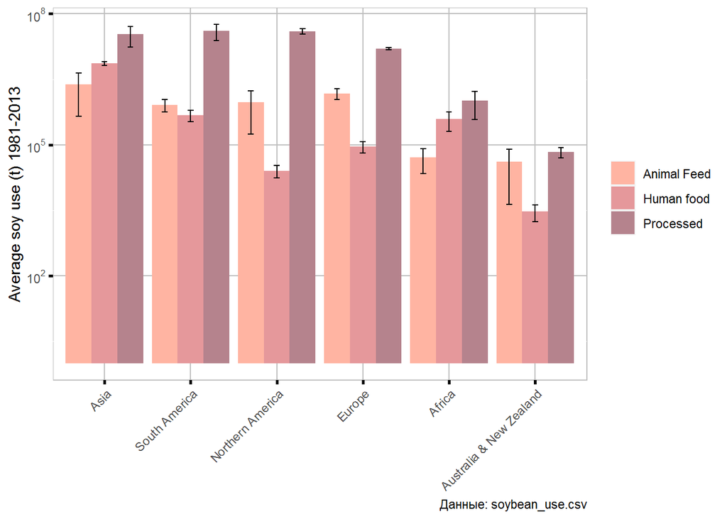

```r
p <- ggplot(soy,
            aes(x = factor(entity, levels = bart$entity),
                y = avg,
                ymin = avg - sd,
                ymax = avg + sd,
                fill = factor(type, levels = c("animal_feed","human_food","processed")))) +
  #Зададим barplot
    geom_bar(stat = "identity", position = "dodge") +
    geom_errorbar(width = 0.2, position = position_dodge(width = 0.9)) +
  #Масштабируем оси и установим метки
    scale_y_continuous(trans='log10', labels = scales::trans_format("log10", scales::math_format(10^.x))) +
  #Введем обозначения
    labs(title="?",
         caption = "Данные: soybean_use.csv",
         x = "Continent",
         y = "Average soy use (t) 1981-2013") +
    scale_fill_manual(values = c("#ffb4a2", "#e5989b", "#b5838d"),
                      labels = c("Animal Feed","Human food","Processed"))  +

  #Зададим собственную тему

    theme(plot.background = element_blank(),
          panel.background = element_rect(fill = "transparent", colour = "gray"),
          panel.grid.major = element_line(colour = "grey"),
          plot.title = element_blank(),
          axis.text.x = element_text(angle = 45, hjust=1),
          axis.ticks = element_line(color = "black",
                                    linewidth = 1),
          axis.title.x = element_blank(),


          legend.position = "right",
          legend.title = element_blank())

p
```

# Задание №4

## Задание №4.1

> Напишите функцию, которая бы рассчитывала ядерно-цитоплазматическое соотношение (“N:C” или “karyoplasmic” ratio) по формуле $\frac{NucleusVol}{CellVol}$, где **NucleusVol** - объем ядра (мкм3), **CellVol** - объем клетки (мкм3).

> На небольшом примере продемонстрируйте работу этой функции.

```r
NC <- function(NucleusVol, CellVol) { #Инициализируем функцию
  NucleusVol/CellVol
}
NC(100,1000) #Продемонстрируем работу функции
```

```
## [1] 0.1
```

## Задание №4.2

> Прочитайте данные по размерам ядер и клеток разных организмов из разнообразных таксономических групп, они находятся по ссылке https://raw.githubusercontent.com/kirushka/datasets/main/NC_ratio.csv. Эти данные взяты из статьи Malerba et al. 2021.

> В прочитанном датафрейме 4 столбца:
- SpeciesGroup - название таксономической группы,
- Species - видовое название организма,
- NucleusVol - объем ядра (мкм3),
- CellVol - объем клетки (мкм3).

> Используя функцию, которую вы создали в предыдущем задании, посчитайте ядерно-цитоплазматическое соотношение (“N:C” или “karyoplasmic” ratio) для каждого организма - запишите результат в новый столбец.

> Также преобразуйте строковый столбец SpeciesGroup в столбец с факторами. Отсортируйте уровни фактора по убыванию медианного значения NC ratio.

```r
#Прочитаем данные
nucel <- read_csv("https://raw.githubusercontent.com/kirushka/datasets/main/NC_ratio.csv")
head(nucel) #Вот такие данные
```

```
## # A tibble: 6 x 4
##   SpeciesGroup       Species            NucleusVol CellVol
##   <chr>              <chr>                   <dbl>   <dbl>
## 1 Amphibians (frogs) acris_crepitans          87.9   3635.
## 2 Amphibians (frogs) acris_gryllus            90.2   1107.
## 3 Amphibians (frogs) bombina_bombina         252.    1796.
## 4 Amphibians (frogs) bombina_orientalis      175.    3186.
## 5 Amphibians (frogs) bombina_variegata       194.    5519.
## 6 Amphibians (frogs) bufo_americanus         110.    1098.
```

```r
#Запишем результат в NqC
nuc <- nucel %>%
  mutate(NqC = NC(NucleusVol,CellVol))
#Преобразуем в столбец с факторами по убыванию медианного значения NC ratio
nuc <- nuc %>%
  mutate(SpeciesGroup = fct_reorder(SpeciesGroup, NqC, .fun = median, .desc = TRUE))
head(nuc)
```

```
## # A tibble: 6 x 5
##   SpeciesGroup       Species            NucleusVol CellVol    NqC
##   <fct>              <chr>                   <dbl>   <dbl>  <dbl>
## 1 Amphibians (frogs) acris_crepitans          87.9   3635. 0.0242
## 2 Amphibians (frogs) acris_gryllus            90.2   1107. 0.0814
## 3 Amphibians (frogs) bombina_bombina         252.    1796. 0.140
## 4 Amphibians (frogs) bombina_orientalis      175.    3186. 0.0549
## 5 Amphibians (frogs) bombina_variegata       194.    5519. 0.0352
## 6 Amphibians (frogs) bufo_americanus         110.    1098. 0.101
```

## Задание №4.3

> По модифицированному датафрейму постройте точковую диаграмму, на которой по оси X отложен объем клеток, по оси Y - NC ratio, цветом показана таксономическая группа.

> Добавьте на график линии тренда, построенные с помощью линейной регрессии, для каждой таксономической группы с помощью geom_smooth(method = “lm”).

> Чтобы использовать на графиках “математические” обозначения, греческие буквы и т.п., например, в подписях осей, можно использовать функцию expression, которой подать на вход все выражение без кавычек. Например, так: ggplot(…) + labs(x = expression(Cell<sub>volume</sub>(mu*m^3))).

> Поменяйте цветовую палитру графика.

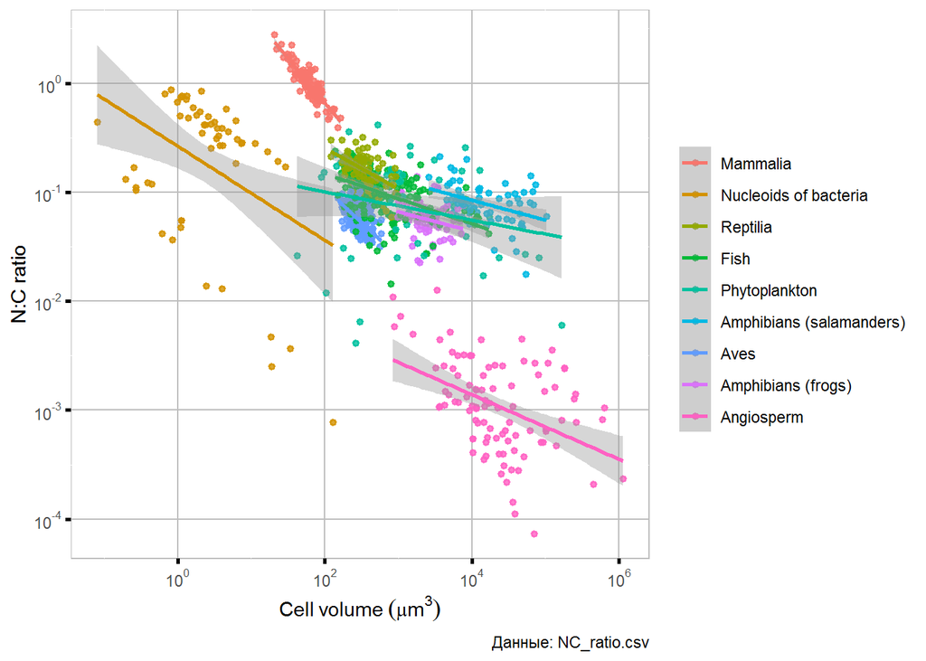

```r
p <- ggplot(data=nuc,
       mapping=aes(x = CellVol,
                   y = NqC,
                   color = SpeciesGroup)) +
  #Зададим порядок значений и стиль точек
    geom_point(shape=19,
               size=1,
               alpha=0.8,
               stroke=1) +
    geom_smooth(method = "lm") + #Линия тренда
    #Масштабируем оси и установим метки
    scale_y_continuous(trans='log10', labels = scales::trans_format("log10", scales::math_format(10^.x))) +
    scale_x_continuous(trans='log10', labels = scales::trans_format("log10", scales::math_format(10^.x))) +
  #Введем легенду по цветам и значениям
    #scale_fill_manual(values = c("#33CC33", "#FF0000","#0000FF","#FFCC00","black"),
    #                  labels = c("Herbivora","Insectivora","Omnivora","Carnivora","NO DATA")) +
  #Введем обозначения
    labs(title="Bigger animals sleep less",
         caption = "Данные: NC_ratio.csv",
         x = expression(Cell~volume~(mu*m^3)),
         y = "N:C ratio") +

  #Зададим собственную тему

    theme(plot.background = element_blank(),
          panel.background = element_rect(fill = "transparent", colour = "gray"),
          panel.grid.major = element_line(colour = "grey"),
          plot.title = element_blank(),
          axis.ticks = element_line(color = "black",
                                    linewidth = 1),
          legend.position = "right",
          legend.title = element_blank())
p
```

## Задание №4.4

> Разделите график из задания 4.3 на “панельки” с помощью facet_wrap, так чтобы каждая таксономическая группа оказалась на своем графике.

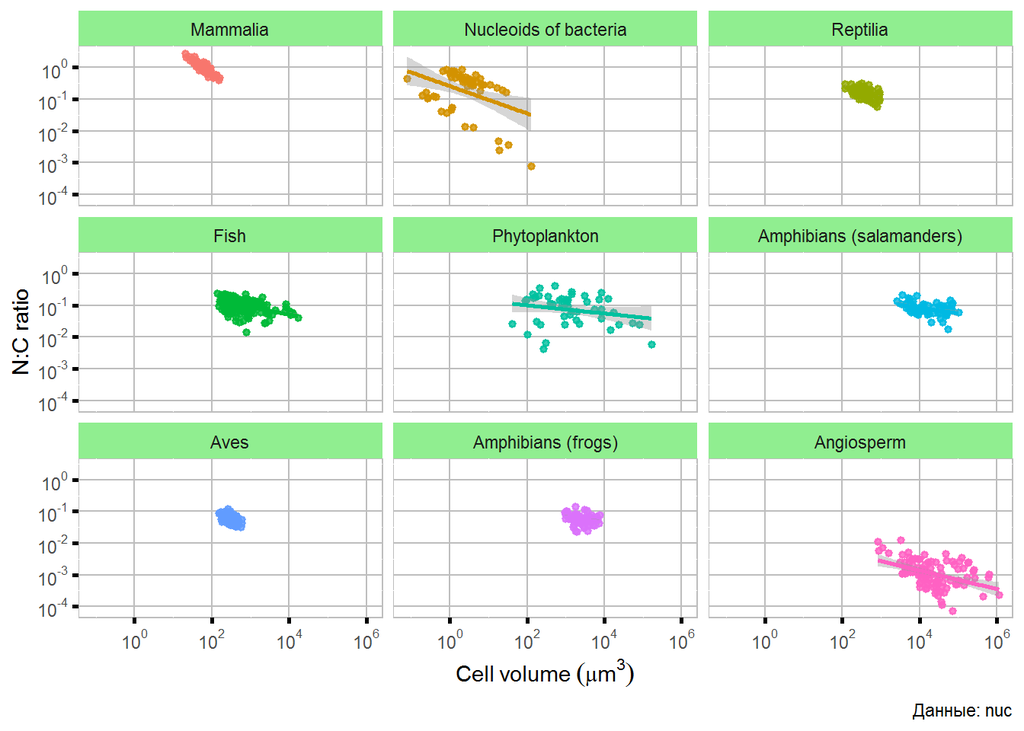

```r
p <- ggplot(data=nuc,
       mapping=aes(x = CellVol,
                   y = NqC,
                   color = SpeciesGroup)) +
  #Зададим порядок значений и стиль точек
    geom_point(shape=19,
               size=1,
               alpha=0.8,
               stroke=1) +
    geom_smooth(method = "lm") + #Линия тренда
    facet_wrap(~ SpeciesGroup) + #Разобьем график
    #Масштабируем оси и установим метки
    scale_y_continuous(trans='log10', labels = scales::trans_format("log10", scales::math_format(10^.x))) +
    scale_x_continuous(trans='log10', labels = scales::trans_format("log10", scales::math_format(10^.x))) +
  #Введем легенду по цветам и значениям
    #scale_fill_manual(values = c("#33CC33", "#FF0000","#0000FF","#FFCC00","black"),
    #                  labels = c("Herbivora","Insectivora","Omnivora","Carnivora","NO DATA")) +
  #Введем обозначения
    labs(title="Bigger animals sleep less",
         caption = "Данные: nuc",
         x = expression(Cell~volume~(mu*m^3)),
         y = "N:C ratio") +

  #Зададим собственную тему

    theme(plot.background = element_blank(),
          panel.background = element_rect(fill = "transparent", colour = "grey"),
          panel.grid.major = element_line(colour = "grey"),
          plot.title = element_blank(),
          axis.ticks = element_line(color = "black",
                                    linewidth = 1),
          strip.background = element_rect(fill = "lightgreen"),
          legend.position = "none",
          legend.title = element_blank())
p
```

# Задание #5

> Напишите несколько функций для моделирования подбрасывания кубика.

## Задание #5.1

> Напишите функцию, которая возвращает результат подбрасывания одного “честного” шестигранного кубика. Продемонстрируйте работу функции. Нужно ли устанавливать seed?

```r
flip_di1 <- function() {
  sides <- 1:6
  sample(sides, 1)
}
set.seed(123)
flip_di1()
```

```
## [1] 3
```

```r
set.seed(300)
flip_di1()
```

```
## [1] 6
```

```r
#Внутри функции устанавливать seed не имеет смысла, если хотите воспроизвести результаты этой функции, то установите seed перед вызовом этой функции.
```

## Задание #5.2

> Напишите функцию, которая возвращает результат подбрасывания двух “честных” шестигранных кубиков. Продемонстрируйте работу функции.

```r
flip_di2 <- function() {
  sides <- 1:6
  list(sample(sides, 2, replace = TRUE))
}
set.seed(123)
flip_di2()
```

```
## [[1]]
## [1] 3 6
```

```r
set.seed(300)
flip_di2()
```

```
## [[1]]
## [1] 6 2
```

## Задание #5.3

> Напишите функцию, которая возвращает результат подбрасывания нескольких “честных” шестигранных кубиков. Число кубиков задается параметром n. Продемонстрируйте работу функции.

```r
flip_din <- function(n) {
  sides <- 1:6
  list(sample(sides, n, replace = TRUE))
}
set.seed(123)
flip_din(5)
```

```
## [[1]]
## [1] 3 6 3 2 2
```

```r
set.seed(300)
flip_din(10)
```

```
## [[1]]
##  [1] 6 2 2 1 4 5 1 4 3 1
```

## Задание #5.4

> Напишите функцию, которая возвращает результат подбрасывания “честного” кубика с заданным числом граней. Число граней задается параметром sides. Продемонстрируйте работу функции.

```r
flip_dis <- function(sides) {
  sidesz <- 1:sides
  list(sample(sidesz, 1, replace = TRUE))
}
set.seed(123)
flip_dis(5)
```

```
## [[1]]
## [1] 3
```

```r
set.seed(300)
flip_dis(10)
```

```
## [[1]]
## [1] 10
```

## Задание #5.5

> Напишите функцию, которая возвращает результат подбрасывания нескольких “честного” кубиков с заданным числом граней. Число граней задается параметром sides (пусть по умолчанию оно будет равно 6). Число кубиков задается параметром n. Продемонстрируйте работу функции.

```r
flip_disn <- function(sides=6,n) {
  sidesz <- 1:sides
  list(sample(sidesz, n, replace = TRUE))
}
set.seed(123)
flip_disn(n=5, sides=10)
```

```
## [[1]]
## [1]  3  3 10  2  6
```

```r
set.seed(300)
flip_disn(n=10, sides = 20)
```

```
## [[1]]
##  [1] 14 10  2  9 19  9 16 13 12  7
```

```r
set.seed(300)
flip_disn(n=10)
```

```
## [[1]]
##  [1] 6 2 2 1 4 5 1 4 3 1
```